# assingment_week_2_brain_tSNE_grid_search

### What steps to do:

1- Load the data

2- Preprocessing

3- Define pipeline with KMean clustering

4- Do PCA and t-SNE to dimention reduction

5- Evaluate

6- Define pipeline with Spectral clustering

7- Do PCA and t-SNE to dimention reduction

8- Evaluate

9- Conclusion

```python
# neaded libraries
import numpy as np
import pandas as pd
import matplotlib.pyplot as plt

from sklearn.preprocessing import StandardScaler
from sklearn.decomposition import PCA
from sklearn.manifold import TSNE
from sklearn.pipeline import Pipeline
from sklearn.cluster import KMeans
from sklearn.cluster import SpectralClustering

from sklearn.model_selection import GridSearchCV
from sklearn.metrics import silhouette_score
```

```python
def plot_data(X, df):
    #add x, y features to the original df
    df['x'] = X[:,0]
    df['y'] = X[:,1]
    sns.scatterplot(x = 'x', y = 'y', hue = 'type', data = df, alpha = 0.5)#, palette=['red','blue'])
    #the len of colors should be as the number of 'type'!
    plt.legend(bbox_to_anchor=(1.05, 1), loc='upper left', borderaxespad=0)
    plt.show()
```

### Loading and preprocessing the data:

```python
df = pd.read_csv('../data/Brain_GSE50161.csv')
```

```python
df.shape
```

```
(130, 54677)
```

```python
df.head()
```

|  | samples | type | 1007_s_at | 1053_at | 117_at | 121_at | 1255_g_at | 1294_at | 1316_at | 1320_at | ... | AFFX-r2-Ec-bioD-3_at | AFFX-r2-Ec-bioD-5_at | AFFX-r2-P1-cre-3_at | AFFX-r2-P1-cre-5_at | AFFX-ThrX-3_at | AFFX-ThrX-5_at | AFFX-ThrX-M_at | AFFX-TrpnX-3_at | AFFX-TrpnX-5_at | AFFX-TrpnX-M_at |
| --- | --- | --- | --- | --- | --- | --- | --- | --- | --- | --- | --- | --- | --- | --- | --- | --- | --- | --- | --- | --- | --- |
| 0 | 834 | ependymoma | 12.498150 | 7.604868 | 6.880934 | 9.027128 | 4.176175 | 7.224920 | 6.085942 | 6.835999 | ... | 9.979005 | 9.926470 | 12.719785 | 12.777792 | 5.403657 | 4.870548 | 4.047380 | 3.721936 | 4.516434 | 4.749940 |
| 1 | 835 | ependymoma | 13.067436 | 7.998090 | 7.209076 | 9.723322 | 4.826126 | 7.539381 | 6.250962 | 8.012549 | ... | 11.924749 | 11.215930 | 13.605662 | 13.401342 | 5.224555 | 4.895315 | 3.786437 | 3.564481 | 4.430891 | 4.491416 |
| 2 | 836 | ependymoma | 13.068179 | 8.573674 | 8.647684 | 9.613002 | 4.396581 | 7.813101 | 6.007746 | 7.178156 | ... | 12.154405 | 11.532460 | 13.764593 | 13.477800 | 5.303565 | 5.052184 | 4.005343 | 3.595382 | 4.563494 | 4.668827 |
| 3 | 837 | ependymoma | 12.456040 | 9.098977 | 6.628784 | 8.517677 | 4.154847 | 8.361843 | 6.596064 | 6.347285 | ... | 11.969072 | 11.288801 | 13.600828 | 13.379029 | 4.953429 | 4.708371 | 3.892318 | 3.759429 | 4.748381 | 4.521275 |
| 4 | 838 | ependymoma | 12.699958 | 8.800721 | 11.556188 | 9.166309 | 4.165891 | 7.923826 | 6.212754 | 6.866387 | ... | 11.411701 | 11.169317 | 13.751442 | 13.803646 | 4.892677 | 4.773806 | 3.796856 | 3.577544 | 4.504385 | 4.541450 |

5 rows × 54677 columns

```python
set(df.type)
```

```
{'ependymoma',
 'glioblastoma',
 'medulloblastoma',
 'normal',
 'pilocytic_astrocytoma'}
```

```python
df['type'].value_counts()
```

```
ependymoma               46
glioblastoma             34
medulloblastoma          22
pilocytic_astrocytoma    15
normal                   13
Name: type, dtype: int64
```

```python
df = df.set_index('samples')
```

```python
data = df.select_dtypes(include=np.number) # to keep the number data
```

```python
data.head()
```

| samples | 1007_s_at | 1053_at | 117_at | 121_at | 1255_g_at | 1294_at | 1316_at | 1320_at | 1405_i_at | 1431_at | ... | AFFX-r2-Ec-bioD-3_at | AFFX-r2-Ec-bioD-5_at | AFFX-r2-P1-cre-3_at | AFFX-r2-P1-cre-5_at | AFFX-ThrX-3_at | AFFX-ThrX-5_at | AFFX-ThrX-M_at | AFFX-TrpnX-3_at | AFFX-TrpnX-5_at | AFFX-TrpnX-M_at |
| --- | --- | --- | --- | --- | --- | --- | --- | --- | --- | --- | --- | --- | --- | --- | --- | --- | --- | --- | --- | --- | --- |
| 834 | 12.498150 | 7.604868 | 6.880934 | 9.027128 | 4.176175 | 7.224920 | 6.085942 | 6.835999 | 5.898355 | 5.513410 | ... | 9.979005 | 9.926470 | 12.719785 | 12.777792 | 5.403657 | 4.870548 | 4.047380 | 3.721936 | 4.516434 | 4.749940 |
| 835 | 13.067436 | 7.998090 | 7.209076 | 9.723322 | 4.826126 | 7.539381 | 6.250962 | 8.012549 | 5.453147 | 6.173106 | ... | 11.924749 | 11.215930 | 13.605662 | 13.401342 | 5.224555 | 4.895315 | 3.786437 | 3.564481 | 4.430891 | 4.491416 |
| 836 | 13.068179 | 8.573674 | 8.647684 | 9.613002 | 4.396581 | 7.813101 | 6.007746 | 7.178156 | 8.400266 | 6.323471 | ... | 12.154405 | 11.532460 | 13.764593 | 13.477800 | 5.303565 | 5.052184 | 4.005343 | 3.595382 | 4.563494 | 4.668827 |
| 837 | 12.456040 | 9.098977 | 6.628784 | 8.517677 | 4.154847 | 8.361843 | 6.596064 | 6.347285 | 4.900380 | 6.008684 | ... | 11.969072 | 11.288801 | 13.600828 | 13.379029 | 4.953429 | 4.708371 | 3.892318 | 3.759429 | 4.748381 | 4.521275 |
| 838 | 12.699958 | 8.800721 | 11.556188 | 9.166309 | 4.165891 | 7.923826 | 6.212754 | 6.866387 | 5.405628 | 5.279579 | ... | 11.411701 | 11.169317 | 13.751442 | 13.803646 | 4.892677 | 4.773806 | 3.796856 | 3.577544 | 4.504385 | 4.541450 |

5 rows × 54675 columns

```python
data.info()
```

```
<class 'pandas.core.frame.DataFrame'>
Int64Index: 130 entries, 834 to 963
Columns: 54675 entries, 1007_s_at to AFFX-TrpnX-M_at
dtypes: float64(54675)
memory usage: 54.2 MB
```

```python
data.describe()
```

|  | 1007_s_at | 1053_at | 117_at | 121_at | 1255_g_at | 1294_at | 1316_at | 1320_at | 1405_i_at | 1431_at | ... | AFFX-r2-Ec-bioD-3_at | AFFX-r2-Ec-bioD-5_at | AFFX-r2-P1-cre-3_at | AFFX-r2-P1-cre-5_at | AFFX-ThrX-3_at | AFFX-ThrX-5_at | AFFX-ThrX-M_at | AFFX-TrpnX-3_at | AFFX-TrpnX-5_at | AFFX-TrpnX-M_at |
| --- | --- | --- | --- | --- | --- | --- | --- | --- | --- | --- | --- | --- | --- | --- | --- | --- | --- | --- | --- | --- | --- |
| count | 130.000000 | 130.000000 | 130.000000 | 130.000000 | 130.000000 | 130.000000 | 130.000000 | 130.000000 | 130.000000 | 130.000000 | ... | 130.000000 | 130.000000 | 130.000000 | 130.000000 | 130.000000 | 130.000000 | 130.000000 | 130.000000 | 130.000000 | 130.000000 |
| mean | 12.276393 | 8.769583 | 7.722634 | 9.160209 | 4.842069 | 7.968388 | 6.800111 | 6.472452 | 6.068968 | 5.548389 | ... | 12.371075 | 11.812911 | 13.793913 | 13.619041 | 5.206208 | 4.811666 | 3.916795 | 3.701539 | 4.627912 | 4.633377 |
| std | 0.790160 | 0.673396 | 1.037339 | 0.615369 | 0.922003 | 0.630260 | 0.537431 | 0.659847 | 0.904152 | 0.627754 | ... | 0.609813 | 0.618190 | 0.320124 | 0.309078 | 0.220767 | 0.219851 | 0.165917 | 0.180251 | 0.160663 | 0.192353 |
| min | 10.156207 | 6.627878 | 6.222515 | 8.044421 | 3.682762 | 6.560920 | 5.910571 | 5.515079 | 4.491771 | 4.572279 | ... | 9.979005 | 9.926470 | 12.719785 | 12.777792 | 4.680072 | 4.247758 | 3.530287 | 3.432622 | 4.278812 | 4.050006 |
| 25% | 11.679721 | 8.378760 | 7.007678 | 8.595505 | 4.207043 | 7.533713 | 6.389605 | 5.935051 | 5.462356 | 5.168066 | ... | 12.056825 | 11.359850 | 13.605871 | 13.392790 | 5.031176 | 4.684169 | 3.807447 | 3.589381 | 4.530391 | 4.519694 |
| 50% | 12.502518 | 8.786242 | 7.521674 | 9.194487 | 4.462729 | 7.915062 | 6.654785 | 6.401447 | 5.856087 | 5.331755 | ... | 12.415320 | 11.768853 | 13.774338 | 13.614493 | 5.214618 | 4.785318 | 3.912025 | 3.674620 | 4.607167 | 4.603287 |
| 75% | 12.883374 | 9.211098 | 8.249157 | 9.707397 | 5.276685 | 8.385912 | 7.143818 | 6.985782 | 6.476124 | 5.740363 | ... | 12.757924 | 12.230375 | 13.969533 | 13.813191 | 5.324326 | 4.950025 | 4.009166 | 3.744824 | 4.718997 | 4.736634 |
| max | 13.655639 | 10.716003 | 12.054143 | 10.407136 | 7.404503 | 10.164655 | 8.110006 | 8.812959 | 8.646862 | 7.607336 | ... | 13.480002 | 13.022222 | 14.476079 | 14.273778 | 5.904952 | 5.619512 | 4.547821 | 4.854368 | 5.420217 | 5.436919 |

8 rows × 54675 columns

```python
#check for missing data
missing = data.isnull().sum()
missing[missing > 0]
```

```
Series([], dtype: int64)
```

```python
#perform log transformation on skewed_columns
# the indexes are the columns of the data, and the second column is the amount of skewness
skew_columns = (data.skew().sort_values(ascending = False)) # make the first column as the index
skew_columns = skew_columns[skew_columns > 0.75] # keep the ones that are more than 0.75

# calculate the log transformation
# this replace each column data with the log transform
for col in skew_columns.index.tolist():
    data[col] = np.log1p(data[col])
data.shape
```

```
(130, 54675)
```

```python
data.head()
```

| samples | 1007_s_at | 1053_at | 117_at | 121_at | 1255_g_at | 1294_at | 1316_at | 1320_at | 1405_i_at | 1431_at | ... | AFFX-r2-Ec-bioD-3_at | AFFX-r2-Ec-bioD-5_at | AFFX-r2-P1-cre-3_at | AFFX-r2-P1-cre-5_at | AFFX-ThrX-3_at | AFFX-ThrX-5_at | AFFX-ThrX-M_at | AFFX-TrpnX-3_at | AFFX-TrpnX-5_at | AFFX-TrpnX-M_at |
| --- | --- | --- | --- | --- | --- | --- | --- | --- | --- | --- | --- | --- | --- | --- | --- | --- | --- | --- | --- | --- | --- |
| 834 | 12.498150 | 7.604868 | 2.064446 | 9.027128 | 1.644066 | 7.224920 | 6.085942 | 6.835999 | 1.931283 | 1.873863 | ... | 9.979005 | 9.926470 | 12.719785 | 12.777792 | 5.403657 | 4.870548 | 4.047380 | 1.552219 | 1.707732 | 1.749189 |
| 835 | 13.067436 | 7.998090 | 2.105240 | 9.723322 | 1.762352 | 7.539381 | 6.250962 | 8.012549 | 1.864568 | 1.970339 | ... | 11.924749 | 11.215930 | 13.605662 | 13.401342 | 5.224555 | 4.895315 | 3.786437 | 1.518305 | 1.692103 | 1.703186 |
| 836 | 13.068179 | 8.573674 | 2.266718 | 9.613002 | 1.685766 | 7.813101 | 6.007746 | 7.178156 | 2.240738 | 1.991084 | ... | 12.154405 | 11.532460 | 13.764593 | 13.477800 | 5.303565 | 5.052184 | 4.005343 | 1.525052 | 1.716226 | 1.734982 |
| 837 | 12.456040 | 9.098977 | 2.031928 | 8.517677 | 1.639938 | 8.361843 | 6.596064 | 6.347285 | 1.775017 | 1.947150 | ... | 11.969072 | 11.288801 | 13.600828 | 13.379029 | 4.953429 | 4.708371 | 3.892318 | 1.560128 | 1.748918 | 1.708609 |
| 838 | 12.699958 | 8.800721 | 2.530214 | 9.166309 | 1.642078 | 7.923826 | 6.212754 | 6.866387 | 1.857177 | 1.837303 | ... | 11.411701 | 11.169317 | 13.751442 | 13.803646 | 4.892677 | 4.773806 | 3.796856 | 1.521163 | 1.705545 | 1.712256 |

5 rows × 54675 columns

### Define a pipeline with preprocessing and clustering (KMeans)

```python
# Scale the features
scaler = StandardScaler()
scaled_data = scaler.fit_transform(data)
```

```python
# Define the pipeline
pipeline = Pipeline([
    ('preprocessing', scaler),
    ('clustering', KMeans(n_clusters=5))  # Assuming 5 clusters
])
# Fit the clustering algorithm on the scaled data
pipeline.fit(scaled_data)
```

```
Pipeline(steps=[('preprocessing', StandardScaler()),
                ('clustering', KMeans(n_clusters=5))])
```

### use PCA and t-SNE for dimension reduction

```python
# Apply dimensionality reduction
pca = PCA(n_components=2)
tsne = TSNE(n_components=2)

reduced_data_pca = pca.fit_transform(scaled_data)
reduced_data_tsne = tsne.fit_transform(scaled_data)
reduced_data_pca_tsne = tsne.fit_transform(reduced_data_pca)
```

### Visualize the dimensions

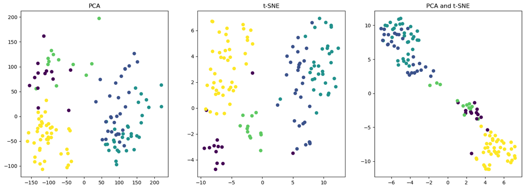

```python
# Plot the reduced data with cluster labels
plt.figure(figsize=(18, 6))

plt.subplot(1, 3, 1)
plt.scatter(reduced_data_pca[:, 0], reduced_data_pca[:, 1], c=pipeline['clustering'].labels_)
plt.title('PCA')

plt.subplot(1, 3, 2)
plt.scatter(reduced_data_tsne[:, 0], reduced_data_tsne[:, 1], c=pipeline['clustering'].labels_)
plt.title('t-SNE')

plt.subplot(1, 3, 3)
plt.scatter(reduced_data_pca_tsne[:, 0], reduced_data_pca_tsne[:, 1], c=pipeline['clustering'].labels_)
plt.title('PCA and t-SNE')

plt.show()
```

### use GridSearchCV to optimize the hyper parameters

```python
# Define the parameter grid
param_grid = {
    'clustering__n_clusters': [2, 3, 4, 5, 6],
    'clustering__init': ['k-means++', 'random']
}

# Perform grid search
grid_search = GridSearchCV(pipeline, param_grid = param_grid, cv=10, n_jobs=-1)
grid_search.fit(scaled_data)
```

```
GridSearchCV(cv=10,
             estimator=Pipeline(steps=[('preprocessing', StandardScaler()),
                                       ('clustering', KMeans(n_clusters=5))]),
             n_jobs=-1,
             param_grid={'clustering__init': ['k-means++', 'random'],
                         'clustering__n_clusters': [2, 3, 4, 5, 6]})
```

## Evaluate the performance of the models

### Silhouette score

The silhouette score is a metric used to assess the quality of clustering results. It measures how well-defined and separated the clusters are based on the distances between data points. The silhouette score takes into account both the cohesion of points within the same cluster (intra-cluster similarity) and the separation between points in different clusters (inter-cluster dissimilarity).

The silhouette score ranges from -1 to 1, with higher values indicating better clustering results:

A silhouette score close to 1 indicates that the data points within each cluster are tightly packed and well-separated from points in other clusters. A silhouette score close to 0 suggests overlapping or ambiguous clusters, where some data points may be on or near the decision boundary between clusters. A silhouette score close to -1 indicates that the data points have been assigned to incorrect clusters or that the clusters are significantly overlapping.

```python
# Get the best estimator and its parameters
best_estimator = grid_search.best_estimator_
best_params = grid_search.best_params_
print('best_estimator: ', best_estimator)
print('best_params: ', best_params)

# Fit the best estimator on the scaled data
best_estimator.fit(scaled_data)

# Evaluate the best estimator
best_labels = best_estimator['clustering'].labels_
silhouette_score = silhouette_score(scaled_data, best_labels)
print('silhouette_score: ', silhouette_score)
```

```
best_estimator:  Pipeline(steps=[('preprocessing', StandardScaler()),
                ('clustering', KMeans(n_clusters=6))])
best_params:  {'clustering__init': 'k-means++', 'clustering__n_clusters': 6}
```

```
silhouette_score:  0.10181599753092363
```

#### Explanation:

The Silhouette score here is 0.1! It suggests that the clustering result is relatively weak.

## Testing the best parameters:

```python
# Define the pipeline
pipeline = Pipeline([
    ('preprocessing', scaler),
    ('clustering', KMeans(init = 'k-means++', n_clusters = 6))
])
# Fit the clustering algorithm on the scaled data
pipeline.fit(scaled_data)
```

```
Pipeline(steps=[('preprocessing', StandardScaler()),
                ('clustering', KMeans(n_clusters=6))])
```

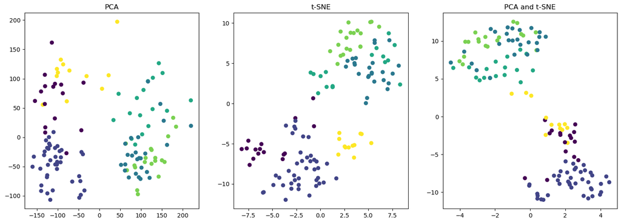

```python
# Plot the reduced data with cluster labels
plt.figure(figsize=(18, 6))

plt.subplot(1, 3, 1)
plt.scatter(reduced_data_pca[:, 0], reduced_data_pca[:, 1], c=pipeline['clustering'].labels_)
plt.title('PCA')

plt.subplot(1, 3, 2)
plt.scatter(reduced_data_tsne[:, 0], reduced_data_tsne[:, 1], c=pipeline['clustering'].labels_)
plt.title('t-SNE')

plt.subplot(1, 3, 3)
plt.scatter(reduced_data_pca_tsne[:, 0], reduced_data_pca_tsne[:, 1], c=pipeline['clustering'].labels_)
plt.title('PCA and t-SNE')

plt.show()
```

### Define a pipeline with preprocessing and clustering (Spectral)

```python
# Scale the features
scaler = StandardScaler()
scaled_data = scaler.fit_transform(data)
```

```python
# Define the pipeline
pipeline = Pipeline([
    ('preprocessing', StandardScaler()),
    ('clustering', SpectralClustering())
])
# Fit the clustering algorithm on the scaled data
pipeline.fit(scaled_data)
```

```
Pipeline(steps=[('preprocessing', StandardScaler()),
                ('clustering', SpectralClustering())])
```

```python
# PCA and t-SNE
# I re-write this steps to keep the steps the same. but I know that the results are the same
# Apply dimensionality reduction
pca = PCA(n_components=2)
tsne = TSNE(n_components=2)

reduced_data_pca = pca.fit_transform(scaled_data)
reduced_data_tsne = tsne.fit_transform(scaled_data)
reduced_data_pca_tsne = tsne.fit_transform(reduced_data_pca)
```

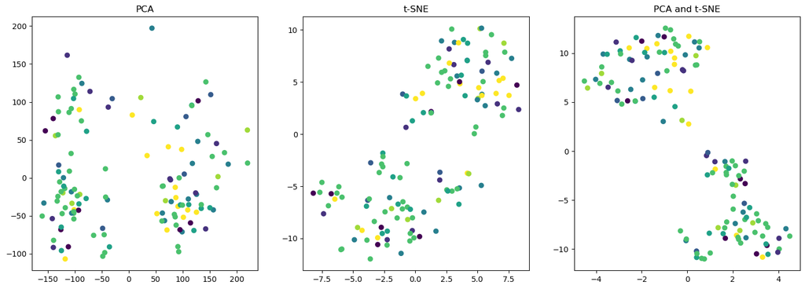

```python
# Plot the reduced data with cluster labels
plt.figure(figsize=(18, 6))

plt.subplot(1, 3, 1)
plt.scatter(reduced_data_pca[:, 0], reduced_data_pca[:, 1], c=pipeline['clustering'].labels_)
plt.title('PCA')

plt.subplot(1, 3, 2)
plt.scatter(reduced_data_tsne[:, 0], reduced_data_tsne[:, 1], c=pipeline['clustering'].labels_)
plt.title('t-SNE')

plt.subplot(1, 3, 3)
plt.scatter(reduced_data_pca_tsne[:, 0], reduced_data_pca_tsne[:, 1], c=pipeline['clustering'].labels_)
plt.title('PCA and t-SNE')

plt.show()
```

```python
def silhouette_scorer(estimator, X):
    labels = estimator['clustering'].labels_
    if len(set(labels)) == 1:
        return -1  # Avoid division by zero when there is only one cluster
    else:
        return silhouette_score(X, labels)
```

```python
# GridSearch:
# Define the parameter grid
param_grid = {
    'clustering__n_clusters': [3, 5, 7],
    'clustering__affinity': ['nearest_neighbors', 'rbf','precomputed_nearest_neighbors'],
    'clustering__gamma': [0.1, 1, 10]
}

# Perform grid search
grid_search = GridSearchCV(pipeline, param_grid = param_grid, cv=10, n_jobs=-1, scoring = silhouette_scorer)
grid_search.fit(scaled_data)
```

[output not shown]

```
GridSearchCV(cv=10,
             estimator=Pipeline(steps=[('preprocessing', StandardScaler()),
                                       ('clustering', SpectralClustering())]),
             n_jobs=-1,
             param_grid={'clustering__affinity': ['nearest_neighbors', 'rbf',
                                                  'precomputed_nearest_neighbors'],
                         'clustering__gamma': [0.1, 1, 10],
                         'clustering__n_clusters': [3, 5, 7]},
             scoring=<function silhouette_scorer at 0x000001C9CF4241F0>)
```

```python
# Get the best estimator and its parameters
best_estimator = grid_search.best_estimator_
best_params = grid_search.best_params_
print('best_estimator: ', best_estimator)
print('best_params: ', best_params)

# Fit the best estimator on the scaled data
best_estimator.fit(scaled_data)

# Evaluate the best estimator
best_labels = best_estimator['clustering'].labels_
silhouette_score = silhouette_score(scaled_data, best_labels)
print('silhouette_score: ', silhouette_score)
```

```
best_estimator:  Pipeline(steps=[('preprocessing', StandardScaler()),
                ('clustering',
                 SpectralClustering(affinity='nearest_neighbors', gamma=0.1,
                                    n_clusters=3))])
best_params:  {'clustering__affinity': 'nearest_neighbors', 'clustering__gamma': 0.1, 'clustering__n_clusters': 3}
```

```
silhouette_score:  0.1671720516887909
```

#### Explanation:

The Silhouette score here is 0.16! It suggests that the clustering result is relatively weak again, But it is a bit better than the KMean clusternig.

```python
# Testing the best parameters:
# Define the pipeline
pipeline = Pipeline([
    ('preprocessing', StandardScaler()),
    ('clustering', SpectralClustering(affinity = 'nearest_neighbors',
                                      gamma = 0.1,
                                      n_clusters = 3))
])
# Fit the clustering algorithm on the scaled data
pipeline.fit(scaled_data)
```

```
Pipeline(steps=[('preprocessing', StandardScaler()),
                ('clustering',
                 SpectralClustering(affinity='nearest_neighbors', gamma=0.1,
                                    n_clusters=3))])
```

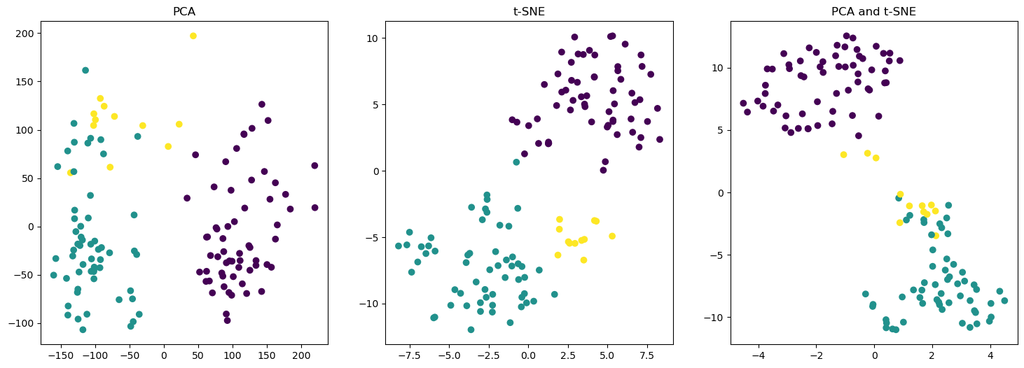

```python
# Plot the reduced data with cluster labels
plt.figure(figsize=(18, 6))

plt.subplot(1, 3, 1)
plt.scatter(reduced_data_pca[:, 0], reduced_data_pca[:, 1], c=pipeline['clustering'].labels_)
plt.title('PCA')

plt.subplot(1, 3, 2)
plt.scatter(reduced_data_tsne[:, 0], reduced_data_tsne[:, 1], c=pipeline['clustering'].labels_)
plt.title('t-SNE')

plt.subplot(1, 3, 3)
plt.scatter(reduced_data_pca_tsne[:, 0], reduced_data_pca_tsne[:, 1], c=pipeline['clustering'].labels_)
plt.title('PCA and t-SNE')

plt.show()
```

## Conclusion:

The pipe line using 2 different clusters (KMean and Spectral) are created. The PCA and t-SNE is done to reduce dimentions and visualize data. Then, with the aid of GridSearch different parameters' options tested to find the best parameters in both clustering methods. The following results are in details:

#### KMean clustering in pipeline:

best_params: {'clustering**init': 'k-means++', 'clustering**n_clusters': 6}

silhouette_score: 0.10181599753092363

#### Spectral clustering in pipeline:

best_params: {'clustering**affinity': 'nearest_neighbors', 'clustering**gamma': 0.1, 'clustering__n_clusters': 3}

silhouette_score: 0.1671720516887909

#### NOTE:

I did dimension reduction in 3 methods, just PCA, just t-SNE, and Both methods together. As the plots indicates, by doing just PCA, the clustering is not sparated clearly. But When I used PCA and then t-SNE, it gives a more clear clustering. The reason is that PCA helps to reduce the dimensionality and capture the major variance in the data, while t-SNE further reduces the dimensionality and emphasizes the local structure, making it easier to visualize and separate the clusters. This combined approach can reveal more distinct clusters and provide a clearer representation of the underlying patterns in the data.